# Study 2b. Within-Subject Manipulation of Wording

Bartosz Maćkiewicz, Katarzyna Kuś, Katarzyna Paprzycka‑Hausman, Marta Zaręba

### Simplified Codebook

- **participant** – Anonymous numeric identifier, unique per participant.
- **PROLIFIC** – Anonymous identifier assigned by Prolific.
- **condition** – Vignette type manipulated between-subjects: Harm or Help.
- **att**– Answer to the attention check question. “A5” is correct.
- **Kc[KnAG]**, **Kc[KnST]**, **Kc[KnPR]** – Agreement with the knowledge statement for each wording, answered on a 7-point Likert scale from -3 (Strongly disagree) to +3 (Strongly agree). These are the within-subject variables.
  - `AG`: Agentive formulation (“…knew that he would harm the environment.”)
  - `ST`: Change of state formulation (“…knew that the environment would be harmed.”)
  - `CA` (PR in raw data): Causal formulation (“…knew that implementing the new program would harm the environment.”)
- **KAGJust**, **KSTJust**, **KPRJust** – Justifications for each knowledge question.
  - (`AGB`) The CEO believed that [side effect would occur].
  - (`AGA`) The CEO was aware that [side effect could occur].
  - (`AGR`) The CEO had reasons to believe that [side effect would occur].
  - (`-oth-`) Other (please specify).
- **KAGNominal**, **KSTNominal**, **KPRNominal** – The three Kc variables converted into categories: Disagree, Agree, and Hesitate.
- **IntChair** – Binary answer to the question “Did the CEO intentionally [harm/help] the environment?”.

# Demographics

A total of 106 participants were included in the final analysis (109 participants were recruited before applying the attention check). The sample’s average age was M = 43.88 (SD = 15.14). The sample included 53 females, 53 males, and 0 individuals who did not disclose their gender.

# Knowledge Attributions

This section analyzes responses to the three knowledge questions presented to each participant.

To what extent do you agree with the following claims:

- [CA] The CEO knew that implementing the new program would harm the environment.
- [AG] The CEO knew that he would harm the environment.
- [ST] The CEO knew that the environment would be harmed.

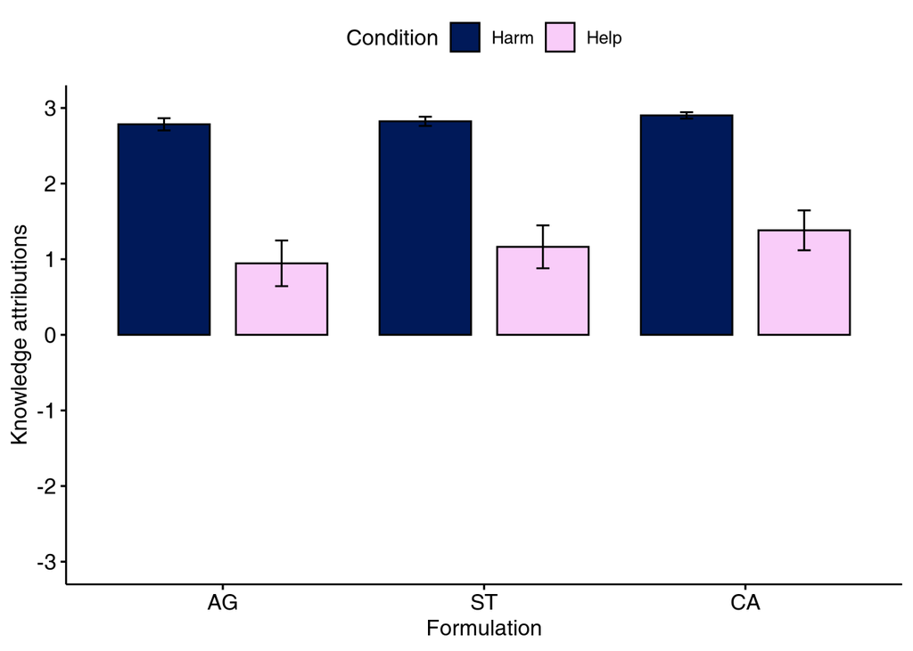

## Descriptive Statistics

| form | condition | M | SD | n |
| --- | --- | --- | --- | --- |
| AG | Harm | 2.78 | 0.58 | 51 |
| AG | Help | 0.95 | 2.24 | 55 |
| CA | Harm | 2.90 | 0.30 | 51 |
| CA | Help | 1.38 | 1.96 | 55 |
| ST | Harm | 2.82 | 0.43 | 51 |
| ST | Help | 1.16 | 2.11 | 55 |

## ANOVA

|  | Effect | DFn | DFd | F | p | p<.05 | ges |
| --- | --- | --- | --- | --- | --- | --- | --- |
| **2** | condition | 1 | 104 | 34.07 | 6.088e-08 | * | 0.229 |
| **3** | form | 2 | 208 | 6.341 | 0.002122 | * | 0.005653 |
| **4** | condition:form | 2 | 208 | 2.015 | 0.136 |  | 0.001803 |

## Pairwise paired t-tests (by Condition)

### Harm Condition

| .y. | group1 | group2 | n1 | n2 | statistic | df | p | p.adj | p.adj.signif |
| --- | --- | --- | --- | --- | --- | --- | --- | --- | --- |
| Kc | AG | CA | 51 | 51 | -1.95 | 50.00 | 0.06 | 0.13 | ns |
| Kc | AG | ST | 51 | 51 | -1.43 | 50.00 | 0.16 | 0.16 | ns |
| Kc | CA | ST | 51 | 51 | 2.06 | 50.00 | 0.04 | 0.13 | ns |

### Help Condition

| .y. | group1 | group2 | n1 | n2 | statistic | df | p | p.adj | p.adj.signif |
| --- | --- | --- | --- | --- | --- | --- | --- | --- | --- |
| Kc | AG | CA | 55 | 55 | -3.25 | 54.00 | 0.00 | 0.01 |  |
| Kc | AG | ST | 55 | 55 | -1.37 | 54.00 | 0.18 | 0.29 | ns |
| Kc | CA | ST | 55 | 55 | 1.47 | 54.00 | 0.15 | 0.29 | ns |

## Pairwise paired t-tests

| .y. | group1 | group2 | n1 | n2 | statistic | df | p | p.adj | p.adj.signif |
| --- | --- | --- | --- | --- | --- | --- | --- | --- | --- |
| Kc | AG | CA | 106 | 106 | -3.69 | 105.00 | 0.00 | 0.00 |  |
| Kc | AG | ST | 106 | 106 | -1.58 | 105.00 | 0.12 | 0.12 | ns |
| Kc | CA | ST | 106 | 106 | 1.91 | 105.00 | 0.06 | 0.12 | ns |

## Order effects

| form | .y. | group1 | group2 | n1 | n2 | p | p.signif | p.adj | p.adj.signif |
| --- | --- | --- | --- | --- | --- | --- | --- | --- | --- |
| AG | Kc | APS | ASP | 18 | 17 | 0.57 | ns | 1.00 | ns |
| AG | Kc | APS | PAS | 18 | 18 | 0.03 |  | 0.44 | ns |
| AG | Kc | ASP | PAS | 17 | 18 | 0.11 | ns | 1.00 | ns |
| AG | Kc | APS | PSA | 18 | 17 | 0.14 | ns | 1.00 | ns |
| AG | Kc | ASP | PSA | 17 | 17 | 0.37 | ns | 1.00 | ns |
| AG | Kc | PAS | PSA | 18 | 17 | 0.49 | ns | 1.00 | ns |
| AG | Kc | APS | SAP | 18 | 16 | 0.37 | ns | 1.00 | ns |
| AG | Kc | ASP | SAP | 17 | 16 | 0.74 | ns | 1.00 | ns |
| AG | Kc | PAS | SAP | 18 | 16 | 0.22 | ns | 1.00 | ns |
| AG | Kc | PSA | SAP | 17 | 16 | 0.58 | ns | 1.00 | ns |
| AG | Kc | APS | SPA | 18 | 20 | 0.27 | ns | 1.00 | ns |
| AG | Kc | ASP | SPA | 17 | 20 | 0.61 | ns | 1.00 | ns |
| AG | Kc | PAS | SPA | 18 | 20 | 0.25 | ns | 1.00 | ns |
| AG | Kc | PSA | SPA | 17 | 20 | 0.67 | ns | 1.00 | ns |
| AG | Kc | SAP | SPA | 16 | 20 | 0.88 | ns | 1.00 | ns |
| CA | Kc | APS | ASP | 18 | 17 | 0.26 | ns | 1.00 | ns |
| CA | Kc | APS | PAS | 18 | 18 | 0.04 |  | 0.62 | ns |
| CA | Kc | ASP | PAS | 17 | 18 | 0.37 | ns | 1.00 | ns |
| CA | Kc | APS | PSA | 18 | 17 | 0.18 | ns | 1.00 | ns |
| CA | Kc | ASP | PSA | 17 | 17 | 0.83 | ns | 1.00 | ns |
| CA | Kc | PAS | PSA | 18 | 17 | 0.49 | ns | 1.00 | ns |
| CA | Kc | APS | SAP | 18 | 16 | 0.18 | ns | 1.00 | ns |
| CA | Kc | ASP | SAP | 17 | 16 | 0.81 | ns | 1.00 | ns |
| CA | Kc | PAS | SAP | 18 | 16 | 0.52 | ns | 1.00 | ns |
| CA | Kc | PSA | SAP | 17 | 16 | 0.98 | ns | 1.00 | ns |
| CA | Kc | APS | SPA | 18 | 20 | 0.34 | ns | 1.00 | ns |
| CA | Kc | ASP | SPA | 17 | 20 | 0.83 | ns | 1.00 | ns |
| CA | Kc | PAS | SPA | 18 | 20 | 0.25 | ns | 1.00 | ns |
| CA | Kc | PSA | SPA | 17 | 20 | 0.66 | ns | 1.00 | ns |
| CA | Kc | SAP | SPA | 16 | 20 | 0.65 | ns | 1.00 | ns |
| ST | Kc | APS | ASP | 18 | 17 | 0.72 | ns | 1.00 | ns |
| ST | Kc | APS | PAS | 18 | 18 | 0.09 | ns | 1.00 | ns |
| ST | Kc | ASP | PAS | 17 | 18 | 0.19 | ns | 1.00 | ns |
| ST | Kc | APS | PSA | 18 | 17 | 0.40 | ns | 1.00 | ns |
| ST | Kc | ASP | PSA | 17 | 17 | 0.63 | ns | 1.00 | ns |
| ST | Kc | PAS | PSA | 18 | 17 | 0.41 | ns | 1.00 | ns |
| ST | Kc | APS | SAP | 18 | 16 | 0.52 | ns | 1.00 | ns |
| ST | Kc | ASP | SAP | 17 | 16 | 0.77 | ns | 1.00 | ns |
| ST | Kc | PAS | SAP | 18 | 16 | 0.31 | ns | 1.00 | ns |
| ST | Kc | PSA | SAP | 17 | 16 | 0.85 | ns | 1.00 | ns |
| ST | Kc | APS | SPA | 18 | 20 | 0.95 | ns | 1.00 | ns |
| ST | Kc | ASP | SPA | 17 | 20 | 0.77 | ns | 1.00 | ns |
| ST | Kc | PAS | SPA | 18 | 20 | 0.10 | ns | 1.00 | ns |
| ST | Kc | PSA | SPA | 17 | 20 | 0.42 | ns | 1.00 | ns |
| ST | Kc | SAP | SPA | 16 | 20 | 0.55 | ns | 1.00 | ns |

|  | Effect | DFn | DFd | F | p | p<.05 | ges |
| --- | --- | --- | --- | --- | --- | --- | --- |
| **2** | condition | 1 | 94 | 36.51 | 3.028e-08 | * | 0.2601 |
| **3** | order | 5 | 94 | 1.47 | 0.2071 |  | 0.06608 |
| **5** | form | 2 | 188 | 6.527 | 0.001818 | * | 0.006545 |
| **4** | condition:order | 5 | 94 | 1.556 | 0.1801 |  | 0.0697 |
| **6** | condition:form | 2 | 188 | 1.786 | 0.1705 |  | 0.001799 |
| **7** | order:form | 10 | 188 | 1.184 | 0.3042 |  | 0.005938 |
| **8** | condition:order:form | 10 | 188 | 1.426 | 0.1714 |  | 0.007145 |

# Intentionality Judgments

This section analyzes responses to the question: *Did the CEO intentionally [harm/help] the environment?* This question was asked once per participant.

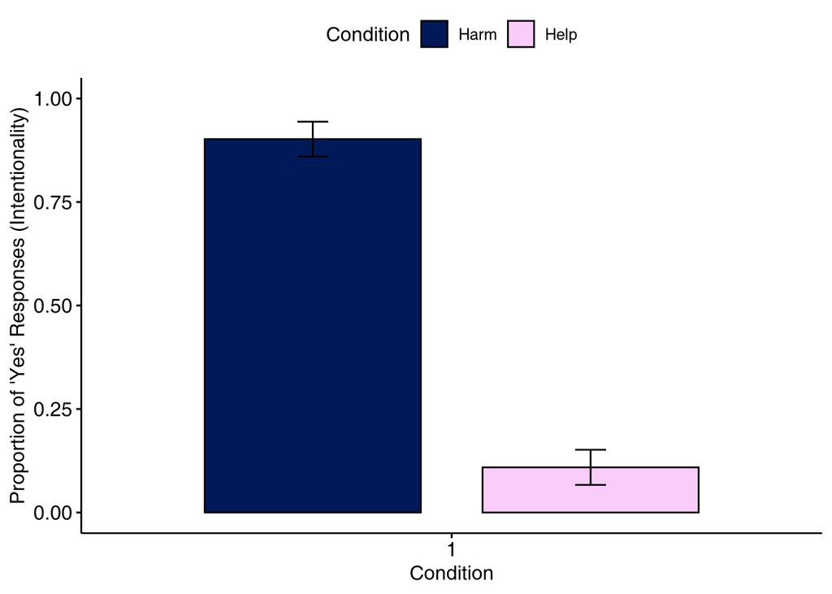

## Descriptive Statistics

| condition | M | SD | n |
| --- | --- | --- | --- |
| Harm | 0.90 | 0.30 | 51 |
| Help | 0.11 | 0.31 | 55 |

# Justification Analysis

This section provides an exploratory analysis of the justifications participants gave for their knowledge attributions.

## Justifications by Knowledge Attribution (`Agree`, `Disagree`, `Hesitate`)

Here, we explore justification patterns separately for participants who agreed, disagreed, or hesitated about the CEO’s knowledge.

### Percentages

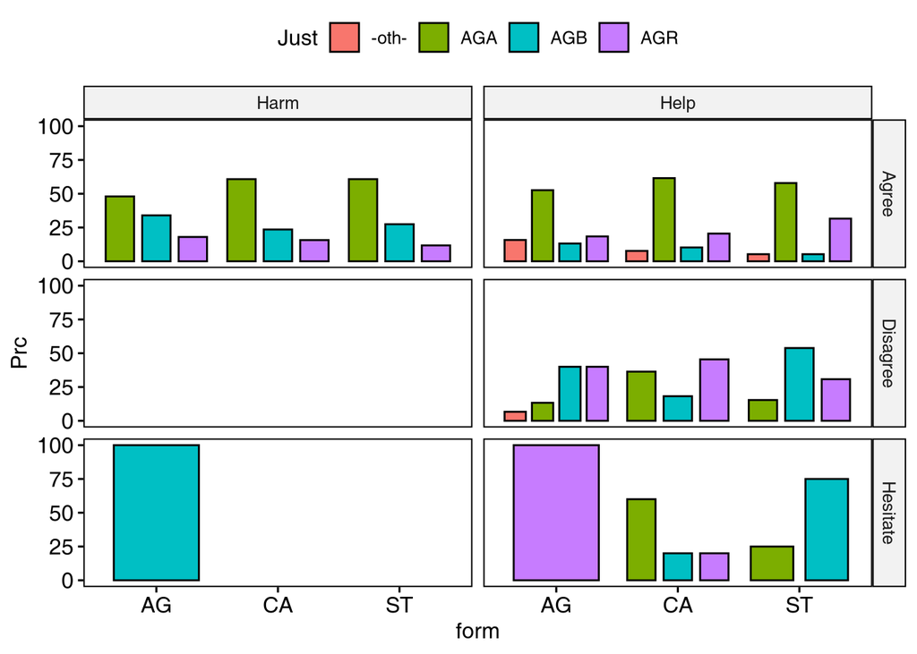

### Counts

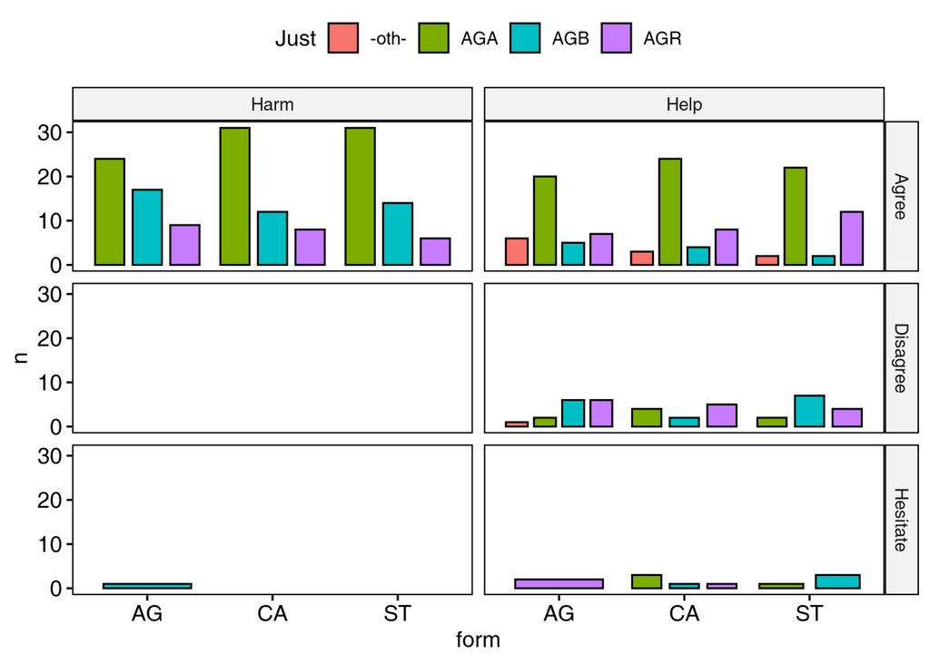

| condition | K | Just | Prc | n | form |
| --- | --- | --- | --- | --- | --- |
| Harm | Agree | AGA | 48.00 | 24 | AG |
| Harm | Agree | AGB | 34.00 | 17 | AG |
| Harm | Agree | AGR | 18.00 | 9 | AG |
| Harm | Hesitate | AGB | 100.00 | 1 | AG |
| Help | Agree | -oth- | 15.79 | 6 | AG |
| Help | Agree | AGA | 52.63 | 20 | AG |
| Help | Agree | AGB | 13.16 | 5 | AG |
| Help | Agree | AGR | 18.42 | 7 | AG |
| Help | Disagree | -oth- | 6.67 | 1 | AG |
| Help | Disagree | AGA | 13.33 | 2 | AG |
| Help | Disagree | AGB | 40.00 | 6 | AG |
| Help | Disagree | AGR | 40.00 | 6 | AG |
| Help | Hesitate | AGR | 100.00 | 2 | AG |
| Harm | Agree | AGA | 60.78 | 31 | CA |
| Harm | Agree | AGB | 23.53 | 12 | CA |
| Harm | Agree | AGR | 15.69 | 8 | CA |
| Help | Agree | -oth- | 7.69 | 3 | CA |
| Help | Agree | AGA | 61.54 | 24 | CA |
| Help | Agree | AGB | 10.26 | 4 | CA |
| Help | Agree | AGR | 20.51 | 8 | CA |
| Help | Disagree | AGA | 36.36 | 4 | CA |
| Help | Disagree | AGB | 18.18 | 2 | CA |
| Help | Disagree | AGR | 45.45 | 5 | CA |
| Help | Hesitate | AGA | 60.00 | 3 | CA |
| Help | Hesitate | AGB | 20.00 | 1 | CA |
| Help | Hesitate | AGR | 20.00 | 1 | CA |
| Harm | Agree | AGA | 60.78 | 31 | ST |
| Harm | Agree | AGB | 27.45 | 14 | ST |
| Harm | Agree | AGR | 11.76 | 6 | ST |
| Help | Agree | -oth- | 5.26 | 2 | ST |
| Help | Agree | AGA | 57.89 | 22 | ST |
| Help | Agree | AGB | 5.26 | 2 | ST |
| Help | Agree | AGR | 31.58 | 12 | ST |
| Help | Disagree | AGA | 15.38 | 2 | ST |
| Help | Disagree | AGB | 53.85 | 7 | ST |
| Help | Disagree | AGR | 30.77 | 4 | ST |
| Help | Hesitate | AGA | 25.00 | 1 | ST |
| Help | Hesitate | AGB | 75.00 | 3 | ST |

## Justifications (Aggregated Across Formulations)

### Percentages

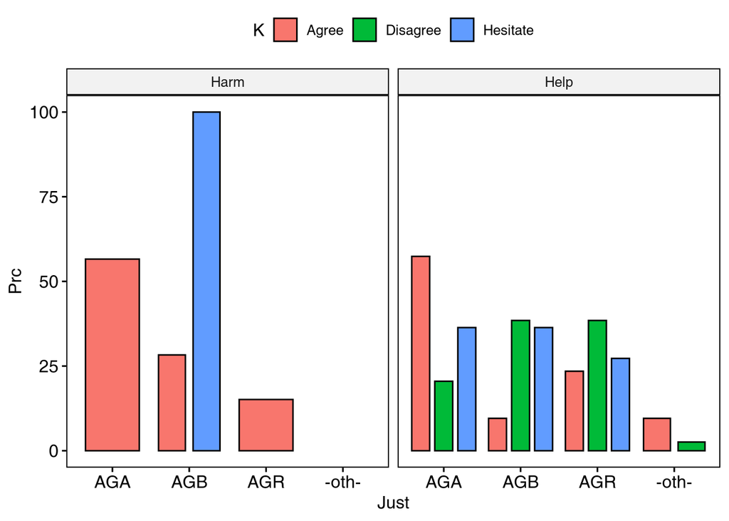

### Counts

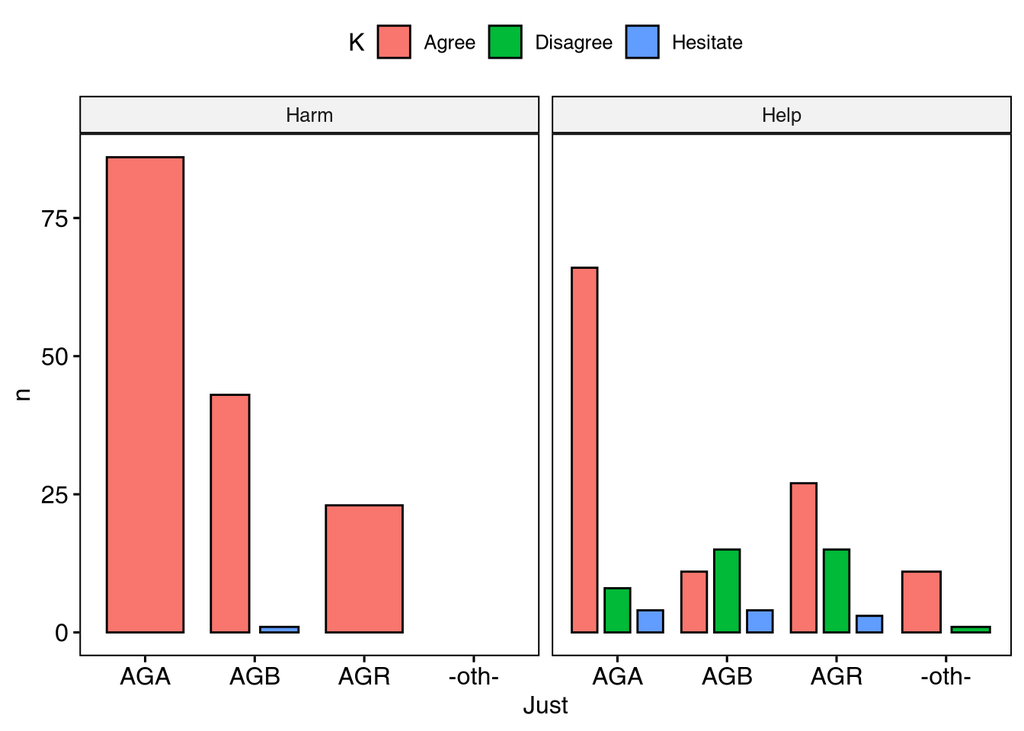

| condition | K | Just | Prc | n |
| --- | --- | --- | --- | --- |
| Harm | Agree | AGA | 56.58 | 86 |
| Harm | Agree | AGB | 28.29 | 43 |
| Harm | Agree | AGR | 15.13 | 23 |
| Harm | Hesitate | AGB | 100.00 | 1 |
| Help | Agree | -oth- | 9.57 | 11 |
| Help | Agree | AGA | 57.39 | 66 |
| Help | Agree | AGB | 9.57 | 11 |
| Help | Agree | AGR | 23.48 | 27 |
| Help | Disagree | -oth- | 2.56 | 1 |
| Help | Disagree | AGA | 20.51 | 8 |
| Help | Disagree | AGB | 38.46 | 15 |
| Help | Disagree | AGR | 38.46 | 15 |
| Help | Hesitate | AGA | 36.36 | 4 |
| Help | Hesitate | AGB | 36.36 | 4 |
| Help | Hesitate | AGR | 27.27 | 3 |

| condition | K | Percent_B | n_B | Percent_A | n_A | Percent_R | n_R | Percent_O | n_O |
| --- | --- | --- | --- | --- | --- | --- | --- | --- | --- |
| Harm | Agree | 28.29 | 43 | 56.58 | 86 | 15.13 | 23 |  |  |
| Harm | Hesitate | 100.00 | 1 |  |  |  |  |  |  |
| Help | Agree | 9.57 | 11 | 57.39 | 66 | 23.48 | 27 | 9.57 | 11 |
| Help | Disagree | 38.46 | 15 | 20.51 | 8 | 38.46 | 15 | 2.56 | 1 |
| Help | Hesitate | 36.36 | 4 | 36.36 | 4 | 27.27 | 3 |  |  |